# Uso y mejora del RNAseqHAB de Arabidopsis (proyecto PRJNA156363)

Using RNAseqHAB pipeline; updated on 17-X-2024

Diego de Pablo, estudiante de herramientas y Algoritmos en Bioinformática, UMA

miércoles 23, octubre 2024. 02.45.15

# Credits and environment

Este trabajo fue realizado gracias a la tutela de M. Gonzalo Claros, quien impartió clases necesarias para entender el funcionamiento de los códigos a usar, además de facilitarnos las diversas herramientas de bioinformática, como mi intención es disminuir todo contenido superfluo, eliminaré algunos espacios que no considero necesarios, y en aquellos casos donde considero que no debería borrar la información pero puede llegar a ser muy ostentoso conteniendo mucha información que para una lectura tenga poca información los guardaré en un cuadro expansible como el siguiente:

**Expande más si quieres leer sobre **Environment**

*RNAseqHAB sourced as interactive from ‘configure_wf.R’*. You can use AS IS without any warrants.

| Environment variables | Value |
| --- | --- |
| **Workflow** name and version | RNAseqHAB v. 231108 |
| Run **date & time** | 2024-10-23_02.45.14 |
| **Linux - unix** | x86_64-pc-linux-gnu |
|  | Linux diegodepab-VirtualBox 6.8.0-47-generic x86_64 |
| **R** version | R version 4.3.3 (2024-02-29) |
| **BioConductor** version | 3.18 |
| **User** | diegodepab |
| PATH to **results** | ~/Descargas/herramientas/tema3/Dataset/RNAseqHAB231108_results_2024-10-23_02.45.14/ |
| **Customisable environment**: |  |
| Packages update | FALSE |
| PATH to **code** files | ~/Descargas/herramientas/tema3/RNAseqHAB/ |
| **Verbose** report | TRUE |

| Customised parameters | Value |
| --- | --- |
| PATH to **data** files | ~/Descargas/herramientas/tema3/Dataset/ |
| Data **files** | kallisto_18.tabular, kallisto_19.tabular, kallisto_20.tabular, kallisto_21.tabular, kallisto_22.tabular, kallisto_23.tabular |
| **Chars to remove** in file names | 9 |
| Columns to read | 1, 4 |
| **Exp. factors** by column | Ler, Ler, Ler, Ler, C24, C24 |
| **Control** (reference) | Ler |
| First **treatment** | C24 |
| All **contrasts** to analyse | C24-Ler |
| **CPM** threshold | 0.5 |
| **Fold-change** threshold | 1.5 (**logFC = 0.5849625**) |
| **P-value** threshold | 0.01 |

# Load data

Se carga archivos de expresión génica en un objeto DEGlist, asigna colores a factores experimentales para representaciones gráficas, y genera visualizaciones como tamaños de librerías, gráficos de escalamiento multidimensional (MDS) y análisis de componentes principales (PCA). Además, guarda los conteos sin procesar en un archivo .tsv.

## Reading file(s)

```r
# use 'x' as a short name since it will be thoroughly used
x <- LoadExpressionData(DATA_FILES, DATA_DIR, EXP_FACTORS, COLUMNS_TO_READ, OTHER_DATA)
```

```
## *** Current sample names:
## [1] "kallisto_18" "kallisto_19" "kallisto_20" "kallisto_21" "kallisto_22" "kallisto_23"
## have been simplified to:
## [1] "18" "19" "20" "21" "22" "23"
```

*Success!*

Counts from **several data files** were read. The corresponding DGEList object was created

```
##                  files group lib.size norm.factors
## 18 kallisto_18.tabular   Ler 70537.01            1
## 19 kallisto_19.tabular   Ler 71894.00            1
## 20 kallisto_20.tabular   Ler 71404.00            1
## 21 kallisto_21.tabular   Ler 72941.00            1
## 22 kallisto_22.tabular   C24 56343.00            1
## 23 kallisto_23.tabular   C24 50633.00            1
```

```r
# borrar constantes que ya no se necesitan
rm(DATA_FILES, COLUMNS_TO_READ, OTHER_DATA)
```

## Assigning colours to factors

A partir de los factores en `EXP_FACTORS`, se identifican los factores únicos y se asigna un color distintivo para cada uno, que se usará en las representaciones gráficas.

```r
# convert experimental factors in colours
UNIQ_FACTORS <- unique(EXP_FACTORS)
EXP_COLORS <- as.vector(EXP_FACTORS)
i <- 1
for (i in 1:length(UNIQ_FACTORS)) {
   # replace each factor by a colour number
   EXP_COLORS <- replace(EXP_COLORS, EXP_COLORS == UNIQ_FACTORS[i], i + 1)
}
```

**Data summary**:

| Property | Value |
| --- | --- |
| Genes | 41671 |
| Samples (conditions) | 6 |
| Unique factors | Ler, C24 |
| Colours | 2, 3 |

## Library sizes and MDS plots

Se grafican los tamaños de las librerías para verificar si están equilibrados, y se generan gráficos de escalamiento multidimensional (MDS) y de análisis de componentes principales (PCA) para mostrar las similitudes entre las muestras.

**Expande más si quieres leer sobre **tamaños de librería MDS and PCA plots**

- Los tamaños de biblioteca sin procesar se revisan para verificar si están equilibrados, lo cual es importante para evitar sesgos en los errores tipo I y la tasa de descubrimiento falso (FDR). Métodos como `voom()` y `glm()` de `limma` manejan mejor las bibliotecas desiguales.
- El escalamiento multidimensional (MDS) reduce las dimensiones a dos para mostrar las similitudes entre muestras, donde se espera que las réplicas formen grupos.
- El análisis de componentes principales (PCA) analiza las correlaciones entre las muestras, permitiendo visualizar agrupaciones de réplicas.

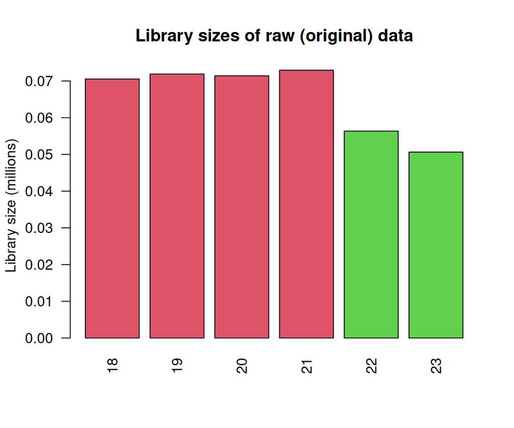

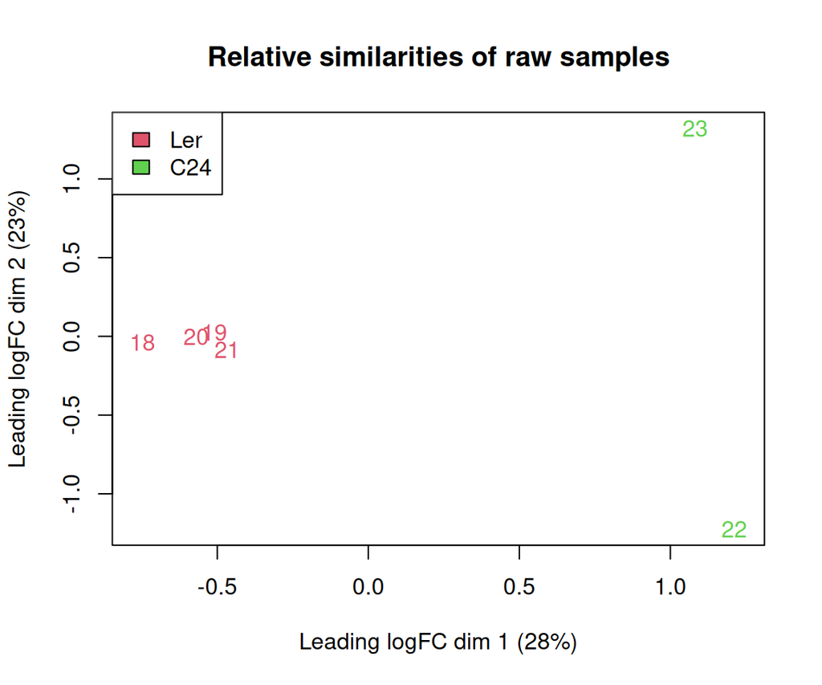

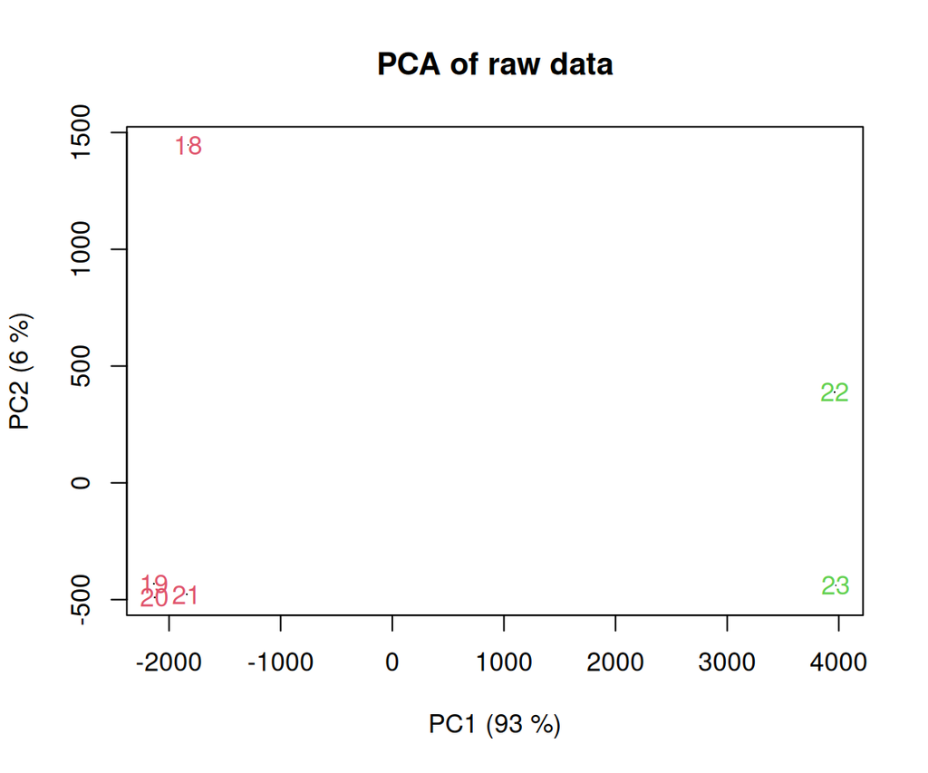

```r
# grasp the names of samples to pinpoint them
COL_NAMES <- colnames(x)

# plot library sizes
barplot(x$samples$lib.size * 1e-6,
        names = COL_NAMES,
        col = EXP_COLORS,
        ylab = "Library size (millions)",
        las = 2,
        main = "Library sizes of raw (original) data")

# multi-dimensional scaling scatterplot
plotMDS(x,
        col = EXP_COLORS,
        main = "Relative similarities of raw samples")

# to indicate the correspondence of colours and factors in both plots
legend("topleft", legend = as.vector(UNIQ_FACTORS), fill = unique(EXP_COLORS))

# PCA, where pca_sum will retain all parameters from the analysis
pca_sum <- PlotMyPCA(x$counts, "PCA of raw data", thisScale = FALSE)
```

**Expande más si quieres leer sobre **Análisis Gráfico**

## Save raw counts

Los conteos sin procesar se guardan en un archivo de *valores separados por tabulaciones* (**.tsv**), donde las filas son códigos de genes y las columnas datos experimentales. Se utilizará la función definida por el usuario `SaveTSV()` para guardar los datos.

```r
fileName <- SaveTSV(x$counts, "rawData-")
message("La tabla de recuentos brutos de todos los genes se guardó en un archivo", "\n", fileName)
```

*Success!*

La tabla de recuentos brutos de todos los genes se guardó en un archivo

~/Descargas/herramientas/tema3/Dataset/RNAseqHAB231108_results_2024-10-23_02.45.14/rawData-2024-10-23_02.45.14.tsv

# Gene filtering

## Genes sin expresión

A continuación, se eliminan los genes que no se expresan (`counts == 0`) en ninguna condición, ya que no tienen interés biológico para este análisis.

```r
# total number of genes
total_genes <- dim(x)[1]
# Looking for genes expressed in all samples
filtered0 <- table(rowSums(x$counts == 0) == 0)
kable(filtered0, col.names = c("Expressed in all samples (TRUE)", "Amount"))

# Counting genes not expressed at all in all samples
COL_NUMBER <- length(COL_NAMES)
all0 <- table(rowSums(x$counts == 0) == COL_NUMBER)
kable(all0, col.names = c("Not expressed in any sample (TRUE)", "Amount"))
```

| Expressed in all samples (TRUE) | Amount |
| --- | --- |
| FALSE | 38119 |
| TRUE | 3552 |

| Not expressed in any sample (TRUE) | Amount |
| --- | --- |
| FALSE | 18660 |
| TRUE | 23011 |

**Resumen**:

[output not shown]

**Expande más si quieres leer sobre **la cantidad de muestras**

El dataset proviene de los resultados del análisis bioinformático de seis librerías de genes de Arabidopsis thaliana (proyecto PRJNA156363). El análisis se llevó a cabo en la plataforma Galaxy, donde las librerías fueron preprocesadas y luego **mapeadas individualmente contra el transcriptoma de Arabidopsis thaliana Col-0 TAIR 10 utilizando Kallisto**. Cabe destacar que si se hubiera utilizado un archivo de diferente tamaño para el mapeo del transcriptoma, podría variar el número de genes evaluados en el proyecto.

## Genes ruidosos

Consideramos *genes ruidosos* los que se expresan poco en todas las muestras.

### Método menos riguroso

En primer lugar, se determina el número mínimo de muestras en las que se espera que haya una expresión fiable, utilizando la constante `EXP_FACTORS` para identificar la condición experimental con menos réplicas.

```r
MIN_REPL <- min(table(EXP_FACTORS))
print(MIN_REPL)
```

```
## [1] 2
```

```r
keep.exprs <- filterByExpr(x, min.count = 5, large.n = MIN_REPL)
filtered2 <- table(keep.exprs) # see in TRUE how many genes pass the filter
x.filt2 <- x[keep.exprs, , keep.lib.sizes = FALSE]  # con el último argumento se recalcula el tamaño de las librerías

kable(filtered2, col.names = c("Low expressed genes in all samples", "Amount"))
```

| Low expressed genes in all samples | Amount |
| --- | --- |
| FALSE | 39207 |
| TRUE | 2464 |

Se estudiarán los genes de la fila TRUE.

### Método riguroso

El objetivo es asegurar que cada gen se exprese de manera **fiable** en al menos una de las réplicas analizadas. Dado que las `counts` dependen del número de lecturas de la librería, se utilizarán las [`CPM`] (cuentas por millón) para evitar que el tamaño afecte los resultados. Este nuevo objeto se denominará `x.cpm`. En lugar de calcularlo sobre la variable original `x`, se realizará sobre el objeto previamente filtrado, `x.filt2`.

```r
x.cpm <- cpm(x.filt2)
```

```r
MIN_CPM
```

```
## [1] 0.5
```

Se filtra más rigor para crear el objeto `x.filt`:

```r
keep.exprs <- rowSums(x.cpm > MIN_CPM) >= MIN_REPL
filteredOK <- table(keep.exprs) # see in TRUE how many genes pass the filter
x.filt <- x.filt2[keep.exprs, , keep.lib.sizes = FALSE]

kable(filteredOK, col.names = c("Expressed less than MIN_CPM", "Amount"))
```

| Expressed less than MIN_CPM | Amount |
| --- | --- |
| TRUE | 2464 |

**Expande más si quieres leer sobre **la expresion de los genes tras filterByExpr:**

| Genes | Recuento |
| --- | --- |
| Total | 41671 |
| No se expresan nunca | 23011 |
| Útiles para estudiar la expresión | 3552 |
| Ídem tras `filterByExpr` | 2464 |
| Ídem tras `CMP >` 0.5 | 2464 |

Para la visualización de los datos, hay que calcular el logaritmo de las [CPM](https://www.reneshbedre.com/blog/expression_units.html):

```r
# borramos variables inútiles
rm(filtered0, all0, filtered2, filteredOK, filteredOK10, keep.exprs, MIN_CPM10, total_genes)
```

‘filteredOK10’ no encontrado

Warning in rm(filtered0, all0, filtered2, filteredOK, filteredOK10, keep.exprs, : objeto ‘MIN_CPM10’

no encontrado

```r
# Calculamos CPM y logCPM de los objetos anteriores
# (ya habíamos calculado antes x.cpm)
x.lcpm <- cpm(x, log = TRUE)

# tras la filtración poco rigurosa
x.filt2.lcpm <- cpm(x.filt2, log = TRUE)
x.filt2.cpm <- cpm(x.filt2)

# tras la filtración rigurosa
x.filt.lcpm <- cpm(x.filt, log = TRUE)
x.filt.cpm <- cpm(x.filt)
```

## Visualización del filtrado

### Density plots

```r
# To define the same range of density for all data
L <- mean(x$samples$lib.size) * 1e-6
M <- median(x$samples$lib.size) * 1e-6
# a cutoff line to sepparate useful from useless genes
genes.cutoff <- log2(10/M + 2/L)
# remove useless variables
rm(L, M)
```

Representación de las 3 gráficas:

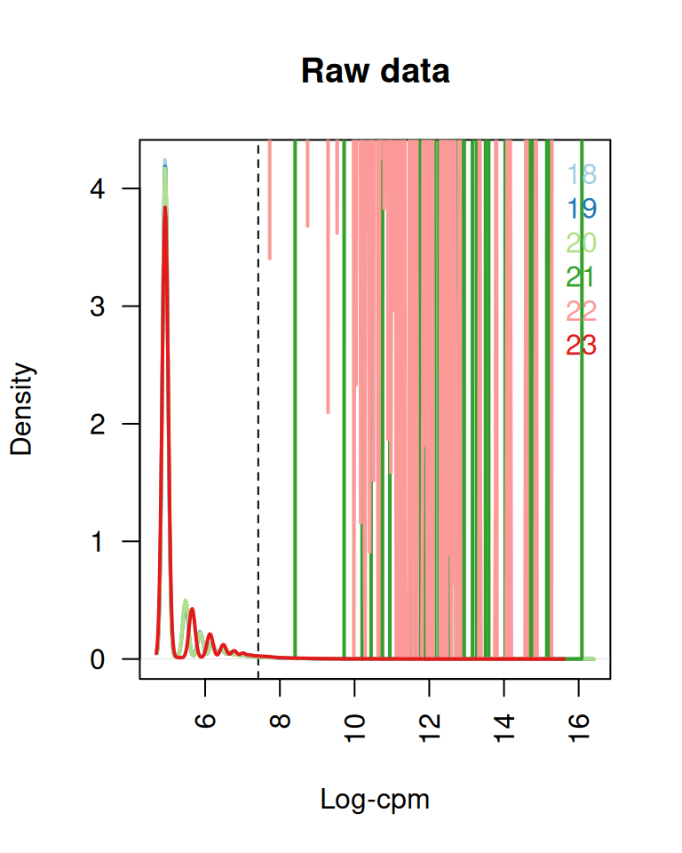

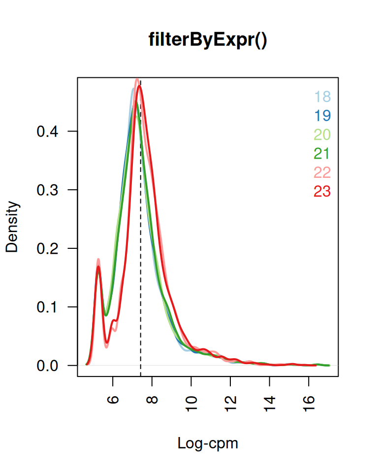

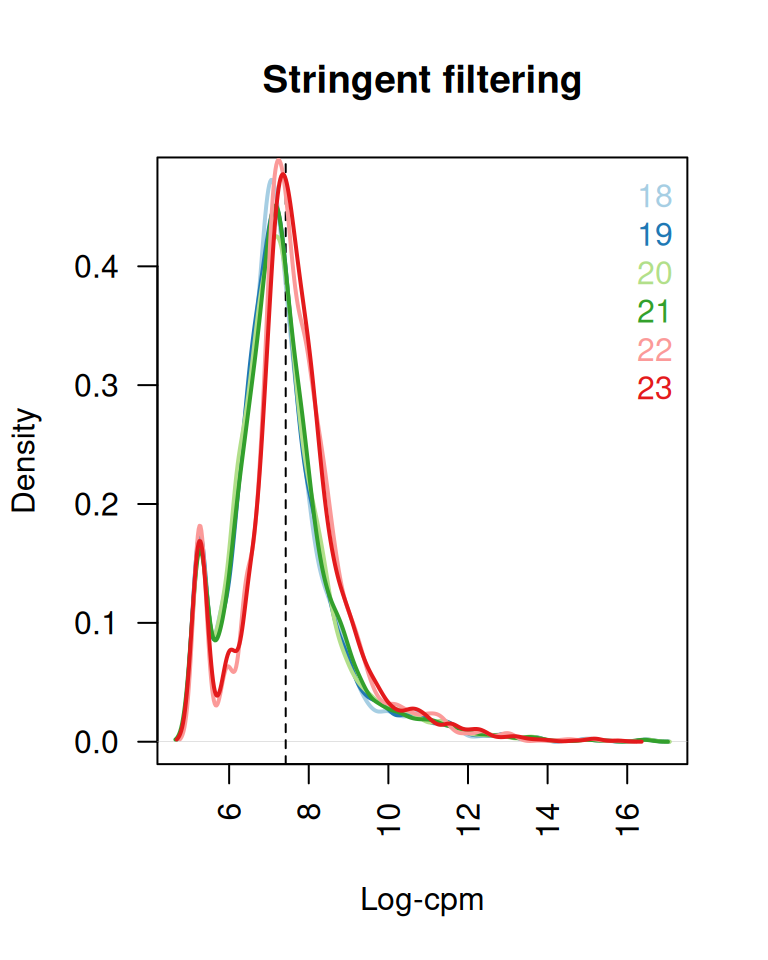

```r
PlotGeneDensity(x.lcpm, genes.cutoff, "Raw data")
PlotGeneDensity(x.filt2.lcpm, genes.cutoff, "filterByExpr()")
PlotGeneDensity(x.filt.lcpm, genes.cutoff, "Stringent filtering")

# remove useless objects to release RAM
rm(genes.cutoff, x.filt2, x.filt2.lcpm, x.filt2.cpm)
```

Tras el filtrado, las líneas de densidad se asemejen a un perfil gaussiano, indicando una reducción en la dispersión al eliminar datos atípicos. Un pico en valores muy bajos de logCPM debería desaparecer.

### New library sizes and MDS

Para comparar sobre el efecto que ha tenido el filtrado sobre el tamaño de las librerías y las gráficas de [MDS](http://www.sthda.com/english/articles/31-principal-component-methods-in-r-practical-guide/122-multidimensional-scaling-essentials-algorithms-and-r-code/) y [PCA](https://builtin.com/data-science/step-step-explanation-principal-component-analysis), las repetimos con los datos filtrados.

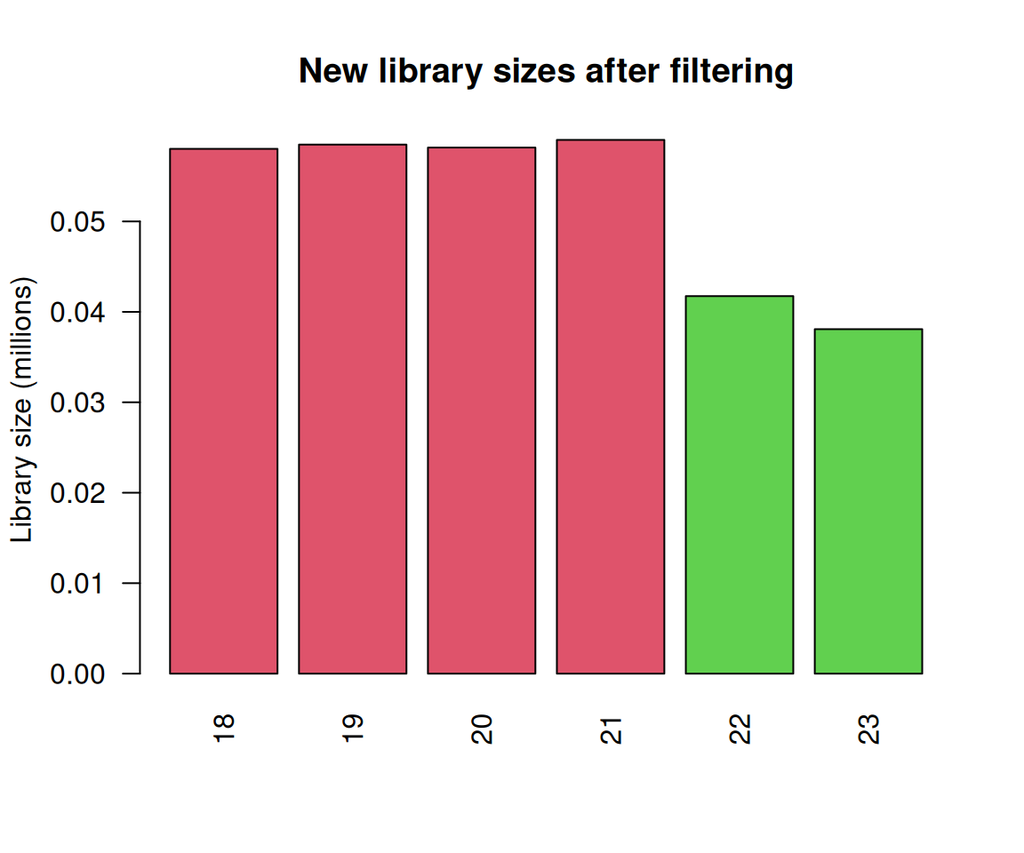

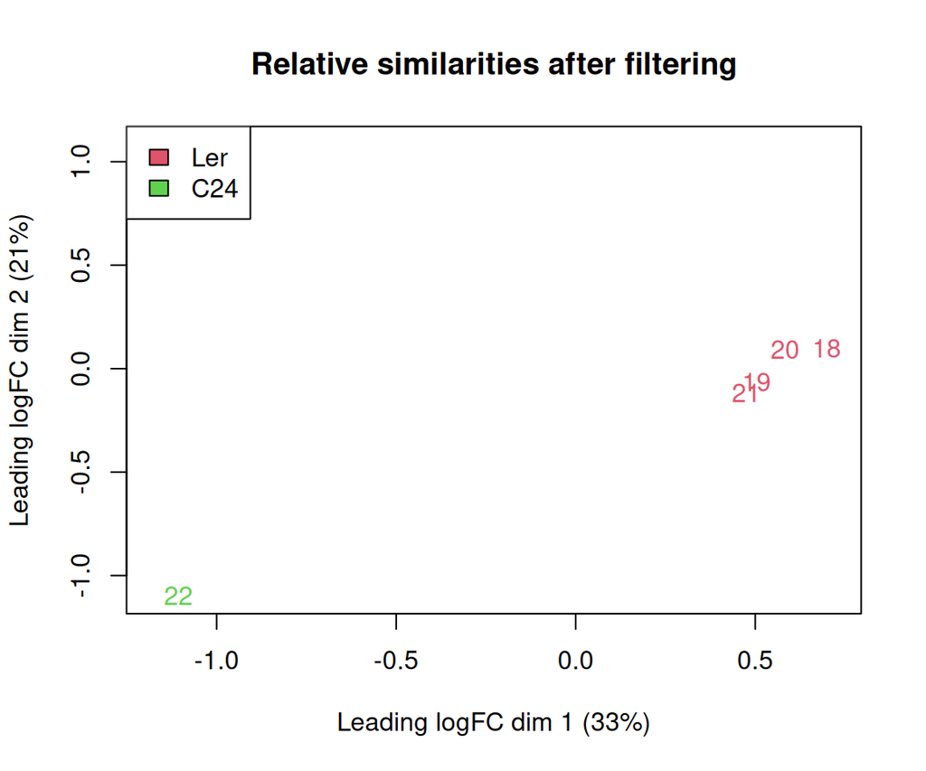

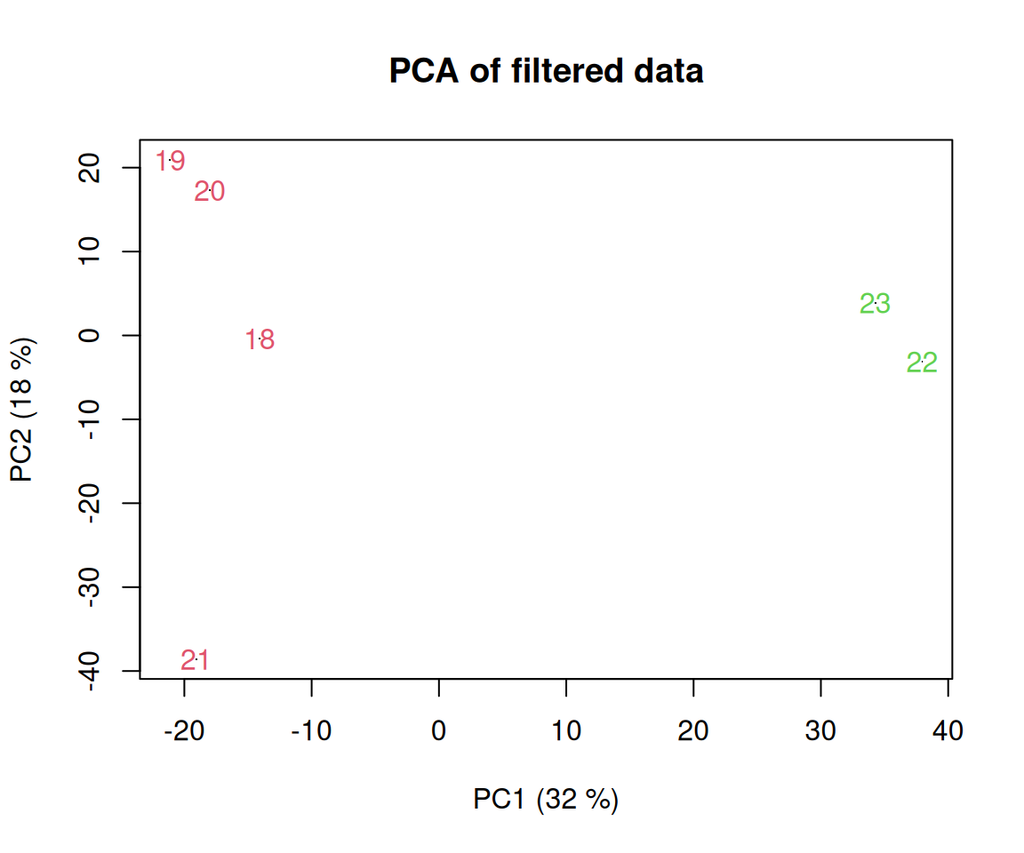

```r
# Reconstruct libsizes after filtering.
# These new, effective library sizes will be used  in all downsteam analyses
x.filt$samples$lib.size <- colSums(x.filt$counts)

# plots
barplot(x.filt$samples$lib.size * 1e-6,
        names = COL_NAMES,
        col = EXP_COLORS,
        ylab = "Library size (millions)",
        las = 2,
        main = "New library sizes after filtering")

plotMDS(x.filt,
        col = EXP_COLORS,
        main = "Relative similarities after filtering")

# common legend
legend("topleft", legend = as.vector(UNIQ_FACTORS), fill = unique(EXP_COLORS))

# if RSeqHAB reports error in this chunk, add "thisScale = FALSE" when calling PlotMyPCA
pca_sum <- PlotMyPCA(x.filt$counts, "PCA of filtered data")
```

## Save filtered counts

Los conteos de genes tras el filtrado se guardan en un archivo **.tsv** (`valores separados por tabulaciones`), donde los códigos de los genes se encuentran en las filas y los datos experimentales en las columnas.

```r
fileName <- SaveTSV(x.filt$counts, "filteredData-")
message(fileName, "\n", "contains filtered gene counts")
```

*Success!*

~/Descargas/herramientas/tema3/Dataset/RNAseqHAB231108_results_2024-10-23_02.45.14/filteredData-2024-10-23_02.45.14.tsv

contains filtered gene counts

# Normalización

e utiliza la función `calcNormFactors()` para calcular factores de escalado que minimizan las diferencias de logFC, normalizando los datos filtrados mediante **TMM**. Los factores de normalización se visualizan en *diagramas de caja* para detectar valores atípicos. La comparación de `logCPM` antes y después de la normalización busca mayor homogeneidad, observándose alineación de medianas y cuartiles tras el proceso. Luego, se evalúa la similitud entre muestras con **MDS** y **PCA**, y se guardan los datos normalizados en formato `.tsv` para futuros análisis.

## Factores de normalización

La función `calcNormFactors()` asume que la mayoría de los genes son estables y utiliza las cuentas de los genes más variables entre muestras para calcular un **factor de escalado**, minimizando las diferencias de `logFC`. Un factor cercano a 1 indica que se requiere menos transformación. Se procederá a normalizar los datos utilizando el filtro riguroso, que ha demostrado ser el más adecuado.

```r
x.filt.norm <- calcNormFactors(x.filt, method = "TMM")
cat("Resulting normalization factors:\n", x.filt.norm$samples$norm.factors, "\n")
```

```
## Resulting normalization factors:
##  0.8586769 0.909254 0.8930779 0.9248477 1.250281 1.240274
```

Representemos ahora estos valores para apreciar mejor si están muy dispersos:

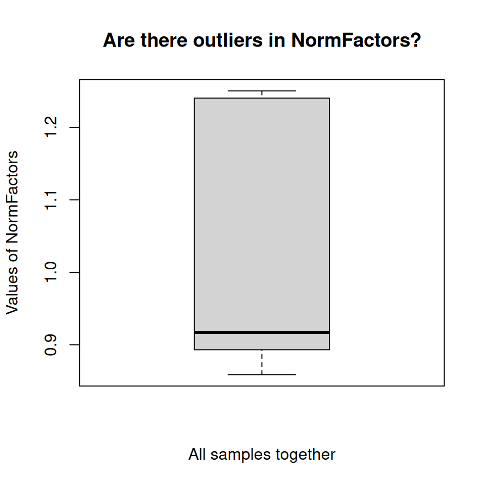

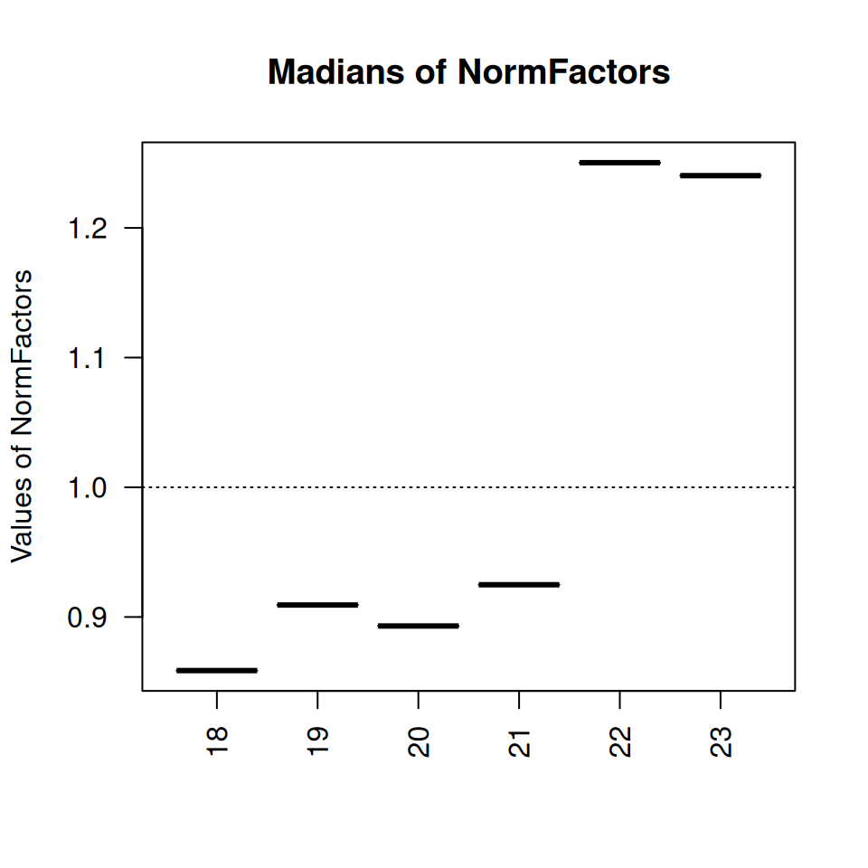

```r
boxplot(x.filt.norm$samples$norm.factors,
        xlab = "All samples together",
        ylab = "Values of NormFactors",
        main = "Are there outliers in NormFactors?")

boxplot(x.filt.norm$samples$norm.factors~rownames(x.filt.norm$samples),
        xlab = "",
        ylab = "Values of NormFactors",
        main = "Madians of NormFactors",
        las = 2)
# línea en 1 para tener una referencia clara
abline(h = 1.0, lty = 3)
```

## Normalizados frente a originales

La distribución de los valores de cada muestra tras filtrado y normalización.

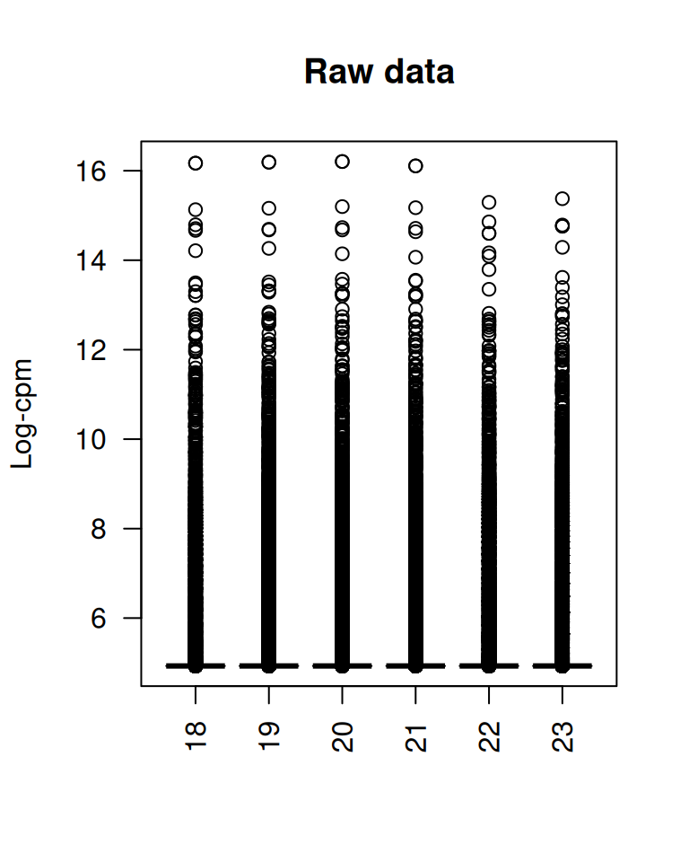

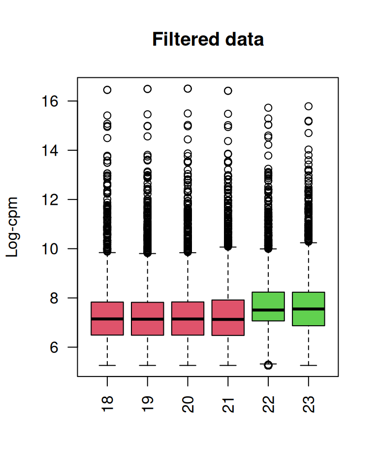

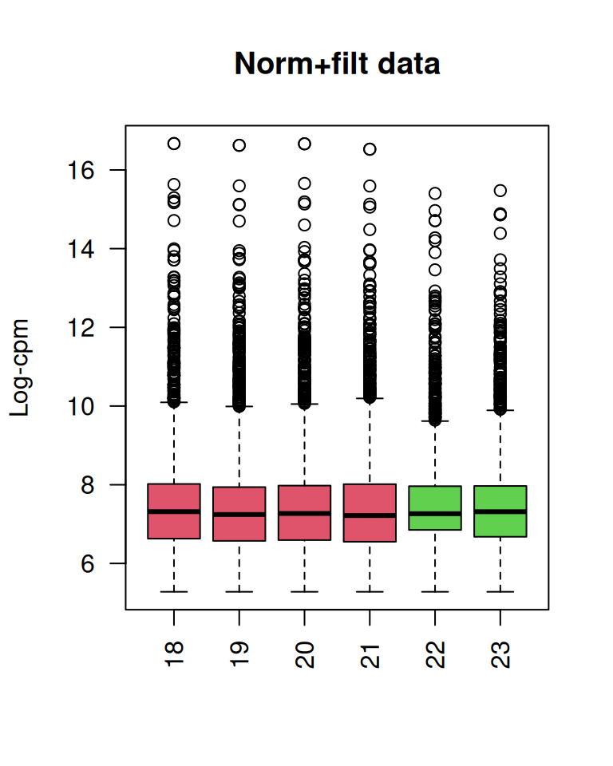

```r
# vamos a usar las logCPM para inspeccionarlo
x.filt.norm.lcpm <- cpm(x.filt.norm, log = TRUE)

boxplot(x.lcpm,
        las = 2,
        col = EXP_COLORS,
        main = RAW_TXT,
        ylab = "Log-cpm")
boxplot(x.filt.lcpm,
        las = 2,
        col = EXP_COLORS,
        main = FILT_TXT,
        ylab = "Log-cpm")
boxplot(x.filt.norm.lcpm,
        las = 2,
        col = EXP_COLORS,
        main = NORM_TXT,
        ylab = "Log-cpm")
```

Efectivamente se cumple lo esperado al normalizar, mostrandose más homogeneo todo.

### Uso de MDS y PCA (Normalizado)

al hacer la representación de los [MDS](http://www.sthda.com/english/articles/31-principal-component-methods-in-r-practical-guide/122-multidimensional-scaling-essentials-algorithms-and-r-code/) para ver si el agrupamiento mejora.

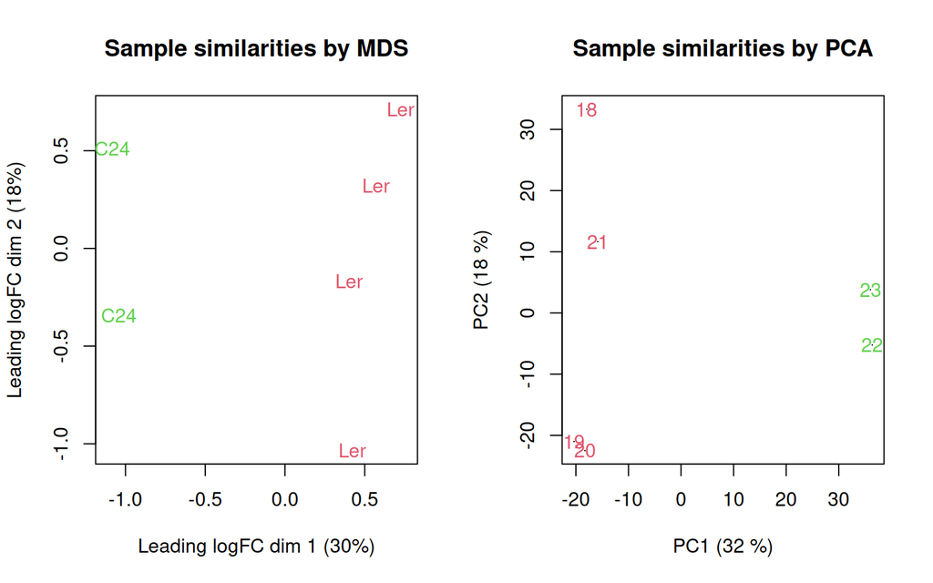

```
##                             PC1      PC2      PC3      PC4      PC5          PC6
## Standard deviation     28.07403 21.11953 20.45698 20.28200 19.99916 5.897341e-14
## Proportion of Variance  0.31987  0.18102  0.16984  0.16695  0.16232 0.000000e+00
## Cumulative Proportion   0.31987  0.50089  0.67073  0.83768  1.00000 1.000000e+00
```

```r
par(mfrow = c(1, 2))
plotMDS(x.filt.norm,
        labels = x.filt.norm$samples$group,
        col = EXP_COLORS,
        main = "Sample similarities by MDS")

# PCA using log-CPM instead of CPM
PlotMyPCA(x.filt.norm.lcpm, "Sample similarities by PCA")
```

**Expande más si quieres leer sobre **comparación de la normalización:**

No existe un gran cambio, no obstante si vemos una mejor distribución entre grupos de la misma condición. lo que sugiere que la normalización, aunque pueda aumentar la dispersión en algunos casos, pero muestra una mejora en la consistencia de los datos trabajados.

## Save normalised data

```r
# traditional method to save normalised CPMs
normCPMs <- cpm(x.filt.norm)
fileName <- SaveTSV(normCPMs, "normalisedCPM-")
message("TMM-normalised **CPMs** were saved in\n", fileName)
```

*Success!*

TMM-normalised **CPMs** were saved in

~/Descargas/herramientas/tema3/Dataset/RNAseqHAB231108_results_2024-10-23_02.45.14/normalisedCPM-2024-10-23_02.45.14.tsv

```r
# to save normalised counts, from https://support.bioconductor.org/p/133671/
norm_counts <- estimateCommonDisp(x.filt.norm, verbose=FALSE)
norm_counts <- estimateTagwiseDisp(norm_counts, trend="none")
norm_count_matrix <- t(t(norm_counts$pseudo.counts)*(norm_counts$samples$norm.factors))
fileName <- SaveTSV(norm_count_matrix, "normalisedCounts-")
message("TMM-normalised **counts** were saved in\n", fileName)
```

*Success!*

TMM-normalised **counts** were saved in

~/Descargas/herramientas/tema3/Dataset/RNAseqHAB231108_results_2024-10-23_02.45.14/normalisedCounts-2024-10-23_02.45.14.tsv

```r
rm(normCPMs, norm_counts, norm_count_matrix)
```

# Define el experimento

El experimento comienza creando una matriz de diseño que asigna a cada muestra su condición experimental mediante `EXP_FACTORS` y `model.matrix()`, ajustando los nombres de las columnas para mayor claridad. Luego, se definen los contrastes necesarios para las comparaciones entre condiciones experimentales, basados en allContrasts del archivo de configuración. En la matriz de contrastes, **0** indica exclusión, **1** incluye la muestra en el numerador y **-1** en el denominador. Esto formaliza el diseño y establece comparaciones entre el control (`CTRL`) y tratamientos (`TREATx`).

## The design as a matrix

Matriz que muestra para que condición fue creada cada dato.

```r
# define el diseño en función de los grupos definidos al cargar los datos
design <- model.matrix(~0+EXP_FACTORS)
# retiramos ahora la palabra "EXP_FACTORS" de cada columna
colnames(design) <- gsub("EXP_FACTORS", "", colnames(design))
# Mostramos el diseño experimental
kable(design, align = "c", caption = "Table describing the experimental design")
```

Table describing the experimental design

| C24 | Ler |
| --- | --- |
| 0 | 1 |
| 0 | 1 |
| 0 | 1 |
| 0 | 1 |
| 1 | 0 |
| 1 | 0 |

## Comparaciones (contrastes)

En este caso al tener solo el grupo Ler y C24, solo se compararán estas dos condiciones.

```r
contr.matrix <- makeContrasts(contrasts = allContrasts, levels = colnames(design))
# Veamos los contrastes:
kable(contr.matrix, align = "c", caption = "Table of contrast that will be analysed")
```

Table of contrast that will be analysed

|  | C24-Ler |
| --- | --- |
| C24 | 1 |
| Ler | -1 |

**Expande más si quieres leer sobre **el significado de los valores de la tabla anterior es el siguiente:**

- **0** indica que la muestra de esa fila no se utilizará en la comparación indicada en la columna.
- **1** indica que la muestra estará en el numerador del cociente, o sea, que los genes con `logFC` positivo se sobreespresarán en ella
- **-1** indica que la muestra estará en el denominador del cociente, o sea, que los genes con `logFC` positivo se subespresarán en ella

# Dispersión en los datos

**Expande si quieres saber más sobre **los códigos a continuación**

La función `estimateDisp()` de [edgeR](http://www.bioconductor.org/packages/release/bioc/html/edgeR.html) se utiliza para evaluar la dispersión de los recuentos de genes en función de las comparaciones definidas en la matriz de diseño. A partir de la dispersión individual de cada gen, se estima la dispersión común, representada en el campo common.dispersion, y se calcula el BCV (biological coefficient of variation), que es la raíz cuadrada de esta dispersión. Los datos se evalúan en diferentes etapas: crudos, filtrados y normalizados, con la expectativa de que la dispersión disminuya en cada paso, lo que indicaría una mejora en la calidad de los datos. Se busca que el BCV se mantenga por debajo de 0.3-0.4, lo que sugiere réplicas técnicas o un experimento bien diseñado. La visualización de los BCV en función de la abundancia de genes permite evaluar si la variación biológica está relacionada con esta abundancia y ayuda a inferir si la dispersión trended se aproxima a una línea común.

## Estimación de la dispersión

```r
# Produce a matrix of pseudo-counts to estimate the common and tagwise dispersions
# use a define 'design' to avoid the switch to the classic mode
x.disp <- estimateDisp(x, design = design) # raw data
x.filt.disp <- estimateDisp(x.filt, design = design) # filtered data
x.filt.norm.disp <- estimateDisp(x.filt.norm, design = design) # filt + norm
```

| **Tipo de datos** | **Dispersión** | **BCV** |
| --- | --- | --- |
| Raw | 0.1767324 | 0.4203955 |
| Filtered | 0.1641858 | 0.4051985 |
| Normalised and filtered | 0.163836 | 0.4047666 |

## Visualización de la dispersión

Los gráficos de BCV de genes, basados en la abundancia, muestran las estimaciones de BCV comunes, de tendencia y genwise, permitiendo inferir si la variación biológica depende de la abundancia de genes.

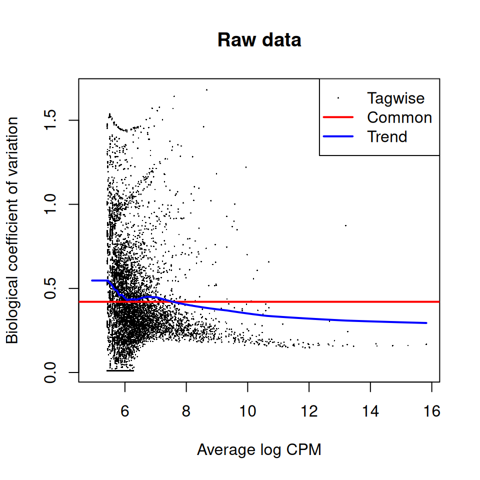

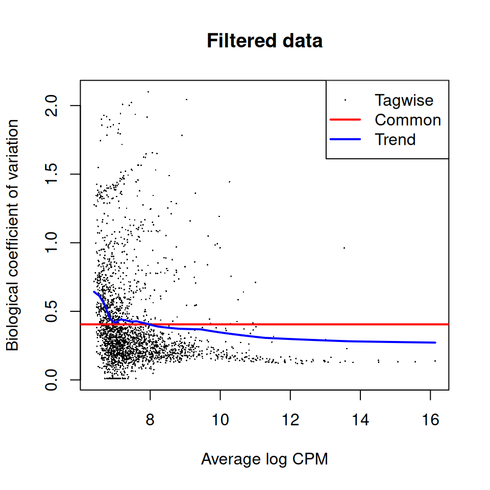

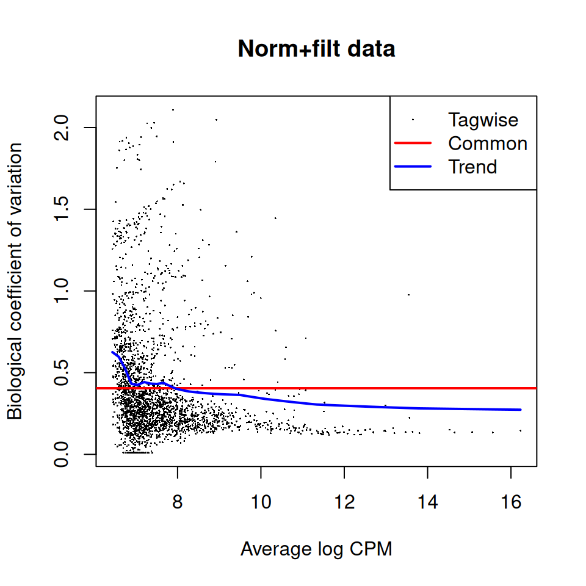

```r
plotBCV(x.disp, main = RAW_TXT)
plotBCV(x.filt.disp, main = FILT_TXT)
plotBCV(x.filt.norm.disp, main = NORM_TXT)

# remove useless variables
rm(x.disp, x.filt.disp)
```

# Expresión diferencial

En este análisis, se evaluaron tres enfoques clave para la expresión diferencial de genes en RNA-seq. El primero, la prueba exacta (exact test), es rápida pero produce muchos falsos positivos. El segundo, el modelo lineal generalizado ajustado con quasi-likelihood (QLF), reduce los falsos positivos y mejora la corrección de la variabilidad biológica. Sin embargo, el tercer método, limma-voom GLM, da los mejores resultados al corregir la heterocedasticidad con voom(), ajustar el modelo con lmFit() y realizar un ajuste bayesiano con eBayes(). Además, la función treat() prioriza genes biológicamente más relevantes, consolidándolo como el enfoque más robusto.

## GLM: Generalised linear model

Antes de hacer el [GLM](https://towardsdatascience.com/generalized-linear-models-9ec4dfe3dc3f) con los datos de RNA-seq, se debe asegurar que los datos son homoescedásticos.

### Heteroescedascidad

Hay que corregir la heteroescedascidad que suelen contener los datos de RNA-seq, sobre todo **cuando el tamaño de las librerías es desigual**. Para ello se usará la función `voom()` de la librería [limma](http://www.bioconductor.org/packages/release/bioc/html/limma.html)

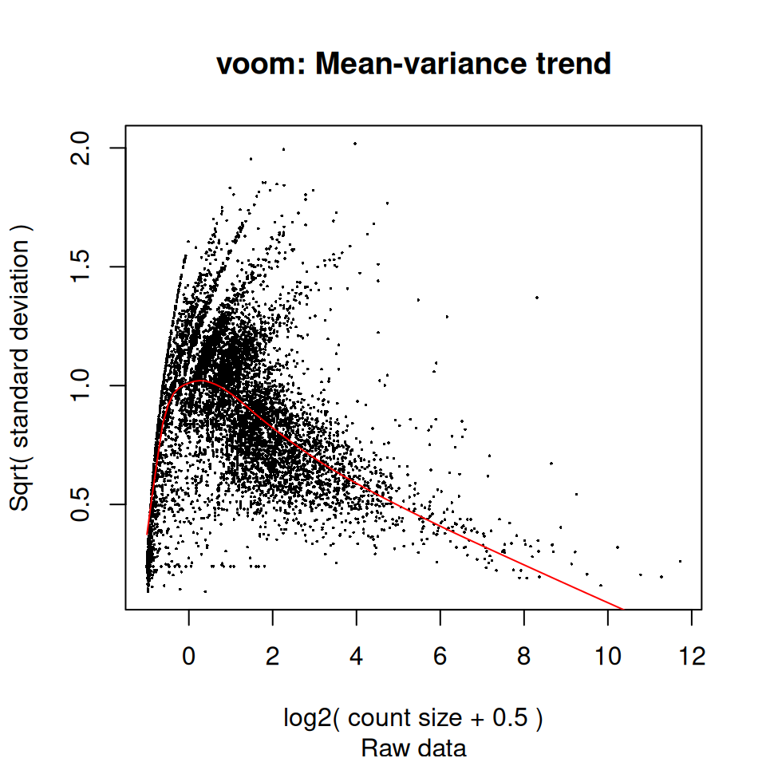

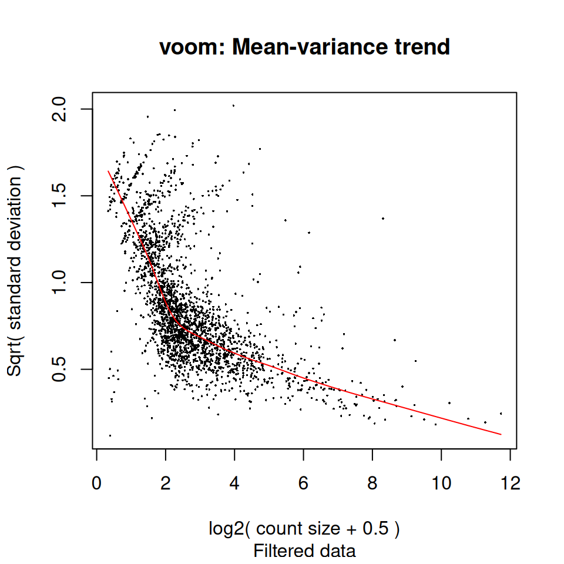

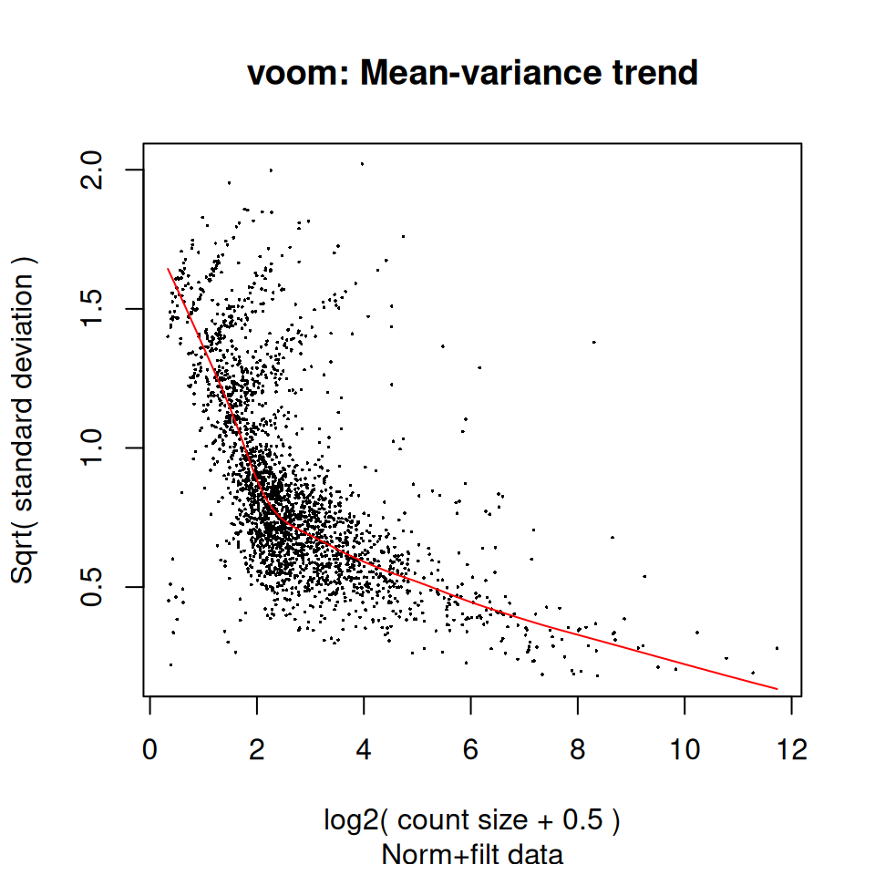

```r
doPlot <- TRUE
v <- voom(x, design, plot = doPlot)
title(sub = RAW_TXT)
v.filt <- voom(x.filt, design, plot = doPlot)
title(sub = FILT_TXT)
v.filt.norm <- voom(x.filt.norm, design, plot = doPlot)
title(sub = NORM_TXT)
```

### Save corrected data

Se guardan los datos homoescedásticos.

```r
fileName <- SaveTSV(v.filt.norm$E, "normHomoscedCPM-")
message("**Filtered, normalised and variance corrected** expression data were saved in\n", fileName)
```

*Success!*

**Filtered, normalised and variance corrected** expression data were saved in

~/Descargas/herramientas/tema3/Dataset/RNAseqHAB231108_results_2024-10-23_02.45.14/normHomoscedCPM-2024-10-23_02.45.14.tsv

```r
# RAW data
v.fit <- lmFit(v, design)
v.fit <- contrasts.fit(v.fit, contrasts = contr.matrix)
v.fit.eB <- eBayes(v.fit)

# for filtered data
v.filt.fit <- lmFit(v.filt, design)
v.filt.fit <- contrasts.fit(v.filt.fit, contrasts = contr.matrix)
v.filt.fit.eB <- eBayes(v.filt.fit)

# for filtered and normalised data
v.filt.norm.fit <- lmFit(v.filt.norm, design)
v.filt.norm.fit <- contrasts.fit(v.filt.norm.fit, contrasts = contr.matrix)
v.filt.norm.fit.eB <- eBayes(v.filt.norm.fit)
```

### Procedimiento con `treat()`

Para priorizar genes con mayor relevancia biológica, se utiliza la función `treat()`, que permite establecer un umbral mínimo de cambio en la expresión (`logFC`). A continuación, se muestra el proceso donde se ajustan los datos originales, filtrados y normalizados utilizando este umbral. Este enfoque garantiza que los genes seleccionados no solo sean estadísticamente significativos, sino también relevantes desde el punto de vista biológico, eliminando aquellos con cambios insignificantes en la expresión.

```r
# RAW data
v.fit.treat <- treat(v.fit, lfc = logFC)
# for filtered data
v.filt.fit.treat <- treat(v.filt.fit, lfc = logFC)
# for filtered and normalised data
v.filt.norm.fit.treat <- treat(v.filt.norm.fit, lfc = logFC)

# remove needless variables
rm(v.fit, v.filt.fit, v.filt.norm.fit)
```

### MD plots (GLM)

Volvemos a usar los umbrales de `P`y `FC` para marcar en **azul** los genes reprimidos y en **rojo** los genes activados.

```r
# Quatifly genes as 1 (up-regulated in red), -1 (down-regulated in blue) or 0 (non significant)
# raw eBayes
eB.status.p.fc <- decideTests(v.fit.eB, p.value = P, lfc = logFC)
# filtered eBayes
eB.filt.status.p.fc <- decideTests(v.filt.fit.eB, p.value = P, lfc = logFC)
# filtered + normalised eBayes
eB.filt.norm.status.p.fc <- decideTests(v.filt.norm.fit.eB, p.value = P, lfc = logFC)

# raw treat
dt.raw <- decideTests(v.fit.treat, p.value = P, lfc = logFC)
# filtered treat
dt.filt <- decideTests(v.filt.fit.treat, p.value = P, lfc = logFC)
# normalised treat
dt.norm <- decideTests(v.filt.norm.fit.treat, p.value = P, lfc = logFC)
```

# Comparación

Se compara los resultados de análisis de expresión diferencial utilizando el método eBayes() en tres conjuntos de datos: originales en bruto, filtrados y normalizados, enfocándose en la comparación TREAT - `CTRL`. Se evalúan los resultados con los valores por defecto de `P` y sin filtrar por `FC`, creando un data frame que resume la cantidad de genes significativos. Luego, se genera un diagrama de Venn para visualizar las intersecciones de los genes diferencialmente expresados (`DEGs`) entre los métodos. A continuación, se repite el análisis utilizando valores configurados de `P` y `FC`, mostrando que se obtienen menos genes, pero con mayor relevancia biológica. Finalmente, se analiza el enfoque `treat()`, generando resultados similares y comparando también los `DEGs` a través de un diagrama de Venn.

### After eBayes()

Se va a comparar las 2 clases de este proyecto a través de:

- *Raw-eB*: Los datos originales en bruto analizados `eBayes()`
- *Filt-eB*: Los datos originales filtrados analizados con `eBayes()`
- *eBayes*: Los datos normalizados analizados con `eBayes()`

La comparación se hará con los valores por defecto de *P* y `FC`, o con los valores configurados como umbral mínimo.

#### Default *P*

Se utiliza decideTests() para evaluar los resultados de tres análisis de expresión diferencial (raw, filtrados y normalizados) con eBayes. Genera un data frame que resume cuántos genes son significativos en cada comparación y muestra estos resultados de forma clara con kable(). Para avanzar, valida los resultados y considera crear un diagrama de Venn para visualizar las intersecciones entre los DEGs identificados por cada método, lo que te permitirá entender mejor la eficacia de cada enfoque.

La función `decideTests()` tiene un valor por defecto de `P = 0.05`, pero no filtra por `FC`. Por tanto, nos quedamos con los genes que tienen un comportamiento fiable, independientemente de si cambian mucho o poco. Ojo, que para el QLF hay que utilizar la función `decideTestsDGE()`

```r
# variables for further Venn
dt.raw1 <- decideTests(v.fit.eB) # Raw + eB
dt.filt1 <- decideTests(v.filt.fit.eB) # Filt + eB
dt.norm1 <- decideTests(v.filt.norm.fit.eB) # Norm + eB

t1 <- as.data.frame(summary(dt.raw1[, 1]))
t2 <- as.data.frame(summary(dt.filt1[, 1]))
t5 <- as.data.frame(summary(dt.norm1[, 1]))
# construye un dataframe con los resultados sin P ni FC
t6 <- cbind(t1, t2[,3], t5[,3])
# renombra las columnas
colnames(t6) <- c("eBayes() y P por defecto", "Contraste", "Raw-eB", "Filt-eB", "eBayes")
kable(t6)
```

| eBayes() y P por defecto | Contraste | Raw-eB | Filt-eB | eBayes |
| --- | --- | --- | --- | --- |
| Down | C24-Ler | 559 | 30 | 61 |
| NotSig | C24-Ler | 13625 | 2343 | 2382 |
| Up | C24-Ler | 27487 | 91 | 21 |

Se crea un diagrama de Venn para visualizar la superposición de genes diferencialmente expresados (DEGs) entre tres conjuntos de datos: los resultados de eBayes sobre datos originales (raw), filtrados (filt) y normalizados (norm). Primero, se identifican los índices de los genes significativos en cada conjunto y se eliminan las variables temporales para optimizar la memoria. Luego, se construye una lista con estos índices y se genera el diagrama de Venn, que muestra las intersecciones y proporciona una representación visual clara de la coincidencia entre los DEGs de los diferentes métodos de análisis.

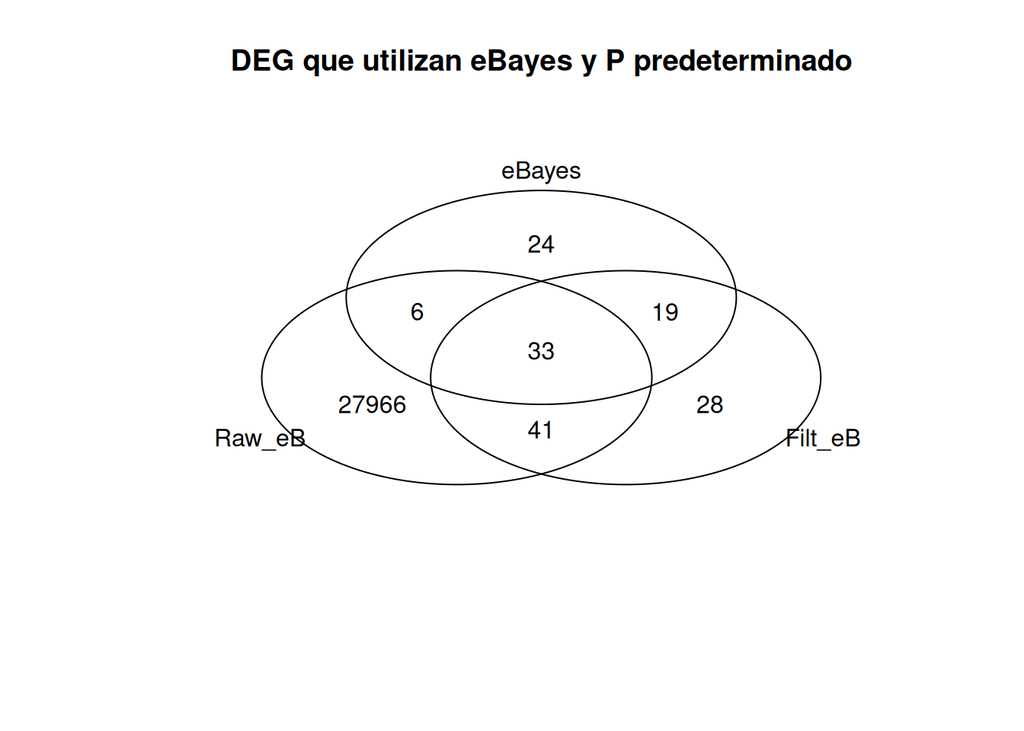

```r
raw.degs <- which(dt.raw1[, 1] != 0)
filt.degs <- which(dt.filt1[, 1] != 0)
norm.degs <- which(dt.norm1[, 1] != 0)

rm( dt.raw1, dt.filt1, dt.norm1)

venn.list <- list(Raw_eB = raw.degs,
                  Filt_eB = filt.degs,
                  eBayes = norm.degs)


venn.matrix <- venn(venn.list,
                    show.plot = TRUE,
                    intersections = TRUE)
title("DEG que utilizan eBayes y P predeterminado")
```

#### Using *P* and *FC*

Pasamos a la función `decideTests()` los valores configurados de *P* y `FC`. Por tanto, nos quedamos con los genes que tienen un comportamiento fiable y que cambian su nivel de expresión al menos `FC` veces.

```r
# el de raw ya se hizo en eB.status.p.fc
# el de Filt ya se hizo en eB.filt.status.p.fc
# el de exact test ya se hizo en eTest.status.p.fc
# el de QLF ya se había calculado como q.test.dt
# el de eBayes ya se hizo en eB.filt.norm.status.p.fc

t1 <- as.data.frame(summary(eB.status.p.fc[, 1]))
t2 <- as.data.frame(summary(eB.filt.status.p.fc[, 1]))
t5 <- as.data.frame(summary(eB.filt.norm.status.p.fc[, 1]))
# construye un dataframe con los resultados con P, FC y eBayes
t6 <- cbind(t1, t2[,3], t5[,3])
# renombra las columnas
colnames(t6) <- c("eBayes(), P y FC configurados", "Contraste", "Raw-eB", "Filt-eB", "eBayes")
kable(t6)
```

| eBayes(), P y FC configurados | Contraste | Raw-eB | Filt-eB | eBayes |
| --- | --- | --- | --- | --- |
| Down | C24-Ler | 279 | 13 | 34 |
| NotSig | C24-Ler | 40585 | 2429 | 2418 |
| Up | C24-Ler | 807 | 22 | 12 |

Vamos a comparar los nuevos resultados:

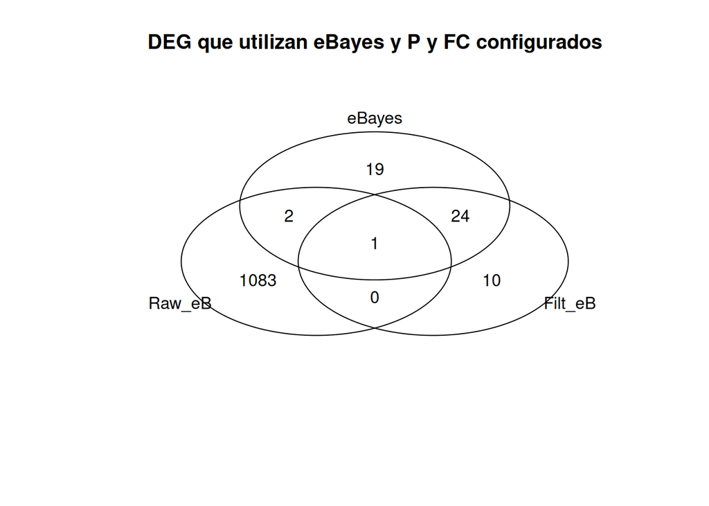

```r
raw.degs <- which(eB.status.p.fc[, 1] != 0)
filt.degs <- which(eB.filt.status.p.fc[, 1] != 0)
norm.degs <- which(eB.filt.norm.status.p.fc[, 1] != 0)

# Create the list to be analysed
venn.list <- list(Raw_eB = raw.degs,
                  Filt_eB = filt.degs,
                  eBayes = norm.degs)

venn.matrix <- venn(venn.list,
                    show.plot = TRUE,
                    intersections = TRUE)
title("DEG que utilizan eBayes y P y FC configurados")
```

### treat() + *P* + *FC*

En este caso, las muestras a comparar serán:

- *Raw-t*: Los datos originales en bruto analizados `treat()`
- *Filt-t*: Los datos originales filtrados analizados con `treat()`
- *Treat*: Los datos normalizados analizados con ``treat()`

```r
t1 <- as.data.frame(summary(dt.raw[, 1]))
t2 <- as.data.frame(summary(dt.filt[, 1]))
t5 <- as.data.frame(summary(dt.norm[, 1]))
t6 <- cbind(t1, t2[,3], t5[,3])
# renombra las columnas
colnames(t6) <- c("treat(), con P y FC", "Contraste", "Raw-t", "Filt-t", "Treat")
kable(t6)
```

| treat(), con P y FC | Contraste | Raw-t | Filt-t | Treat |
| --- | --- | --- | --- | --- |
| Down | C24-Ler | 24 | 9 | 13 |
| NotSig | C24-Ler | 41572 | 2447 | 2450 |
| Up | C24-Ler | 75 | 8 | 1 |

```r
rm(t1, t2, t5, t6)
```

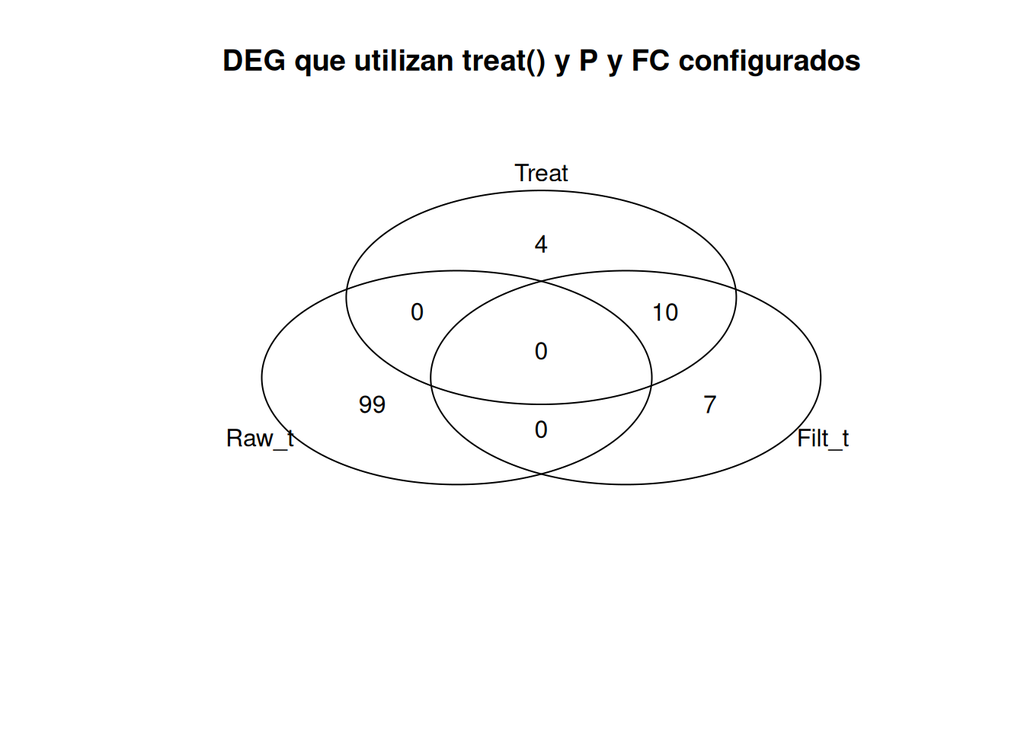

```r
raw.degs <- which(dt.raw[, 1] != 0)
filt.degs <- which(dt.filt[, 1] != 0)
norm.degs <- which(dt.norm[, 1] != 0)

# Create the list to be analysed
venn.list <- list(Raw_t = raw.degs,
                  Filt_t = filt.degs,
                  Treat = norm.degs)

# venn.matrix will store all intersection information
venn.matrix <- venn(venn.list,
                    show.plot = TRUE,
                    intersections = TRUE)
title("DEG que utilizan treat() y P y FC configurados")
```

# DEGs per contrast

## Plot every contrast

Veamos el número de genes que sale con expresión diferencial en cada contraste con los distintos tipos de datos usados, y se comparará con el mejor análisis obtanido con `eBayes()`.

```r
# join per rows the summary tables of eBayes and treat, with an intermediate title
tmp <- rbind(EBAYES="", summary(eB.filt.norm.status.p.fc),
             RAW_t = "", summary(dt.raw),
             FILT_t = "", summary(dt.filt),
             TREAT="", summary(dt.norm))
# display the summary table
kable(as.data.frame(tmp), align ="r", caption = "Orientative number of DEGs per contrast depending on the analysis")
```

Orientative number of DEGs per contrast depending on the analysis

|  | C24-Ler |
| --- | --- |
| EBAYES |  |
| Down | 34 |
| NotSig | 2418 |
| Up | 12 |
| RAW_t |  |
| Down.1 | 24 |
| NotSig.1 | 41572 |
| Up.1 | 75 |
| FILT_t |  |
| Down.2 | 9 |
| NotSig.2 | 2447 |
| Up.2 | 8 |
| TREAT |  |
| Down.3 | 13 |
| NotSig.3 | 2450 |
| Up.3 | 1 |

Representemos las gráficas MD en paralelo para `eBayes()`y `treat()`, puesto que los candidatos de `treat()` estarán siempre contenidos en `eBayes()`.

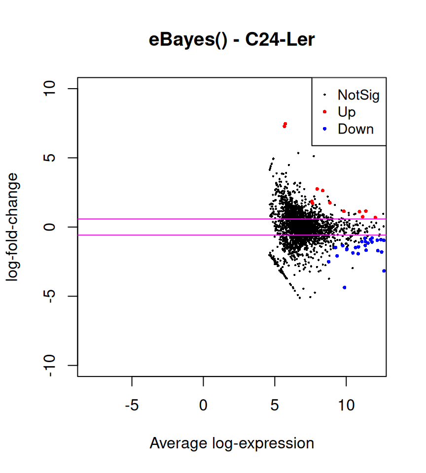

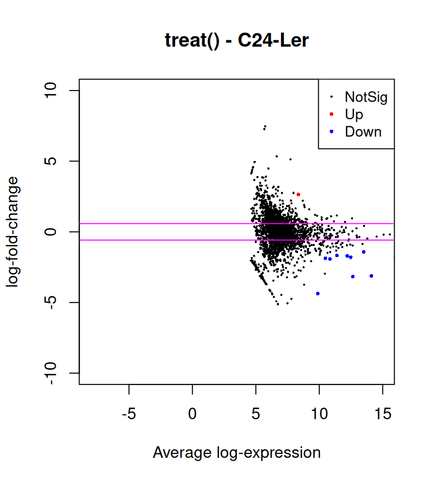

```r
# a variable for the number of contrasts to study.
NUM_CONTRASTS <- length(allContrasts)
i <- 1
for (i in 1:NUM_CONTRASTS) {
  # plot for eBayes
  plotMD(v.filt.norm.fit.eB,
         column = i,
         status = eB.filt.norm.status.p.fc[ ,i],
         main = paste0("eBayes() - ", colnames(eB.filt.norm.status.p.fc)[i]),
         xlim = c(-8, 12),
         ylim = c(-10, 10),
         hl.cex=0.5)
  # mark logFC cutoffs
  abline(h = c(-logFC, logFC), col = "magenta")

  # plot for treat
  plotMD(v.filt.norm.fit.treat,
         column = i,
         status = dt.norm[ ,i],
         main = paste0("treat() - ", colnames(v.filt.norm.fit.treat)[i]),
         xlim = c(-8, 15),
         ylim = c(-10, 10),
         hl.cex=0.5)
  # mark logFC cutoffs
  abline(h = c(-logFC, logFC), col = "magenta")
}
```

## After GLM

```r
# only DEGs
i <- 1
allFiles <- vector()
for (i in 1:NUM_CONTRASTS) {
  theContrast <- colnames(v.filt.norm.fit.eB$contrasts)[i]
  degs.to.save.eB <- topTreat(v.filt.norm.fit.eB,
                               coef = i,
                               adjust.method = "BH",
                               p.value = P,
                               lfc = logFC,
                               resort.by = "logFC",
                               number = Inf)
  fileName <- SaveTSV(degs.to.save.eB, paste0("DEGs_", theContrast, "_GLM-eB-P-", P, "_FC-", FC, "_"))
  allFiles <- c(allFiles, fileName)
}
  message("DEGs for every contrast after GLM-eBayes were saved in files ", "\n", toString(allFiles))
```

*Success!*

DEGs for every contrast after GLM-eBayes were saved in files

~/Descargas/herramientas/tema3/Dataset/RNAseqHAB231108_results_2024-10-23_02.45.14/DEGs_C24-Ler_GLM-eB-P-0.01_FC-1.5_2024-10-23_02.45.14.tsv

Se guarda tanto los DEG como todos los genes los obtenidos con `treat()`:

```r
# only DEGs
i <- 1
allFiles <- vector()
for (i in 1:NUM_CONTRASTS) {
  theContrast <- colnames(v.filt.norm.fit.treat$contrasts)[i]
  table.to.save.glm_treat <- topTreat(v.filt.norm.fit.treat,
                               coef = i,
                               adjust.method = "BH",
                               p.value = P,
                               lfc = logFC,
                               resort.by = "logFC",
                               number = Inf)
  fileName <- SaveTSV(table.to.save.glm_treat, paste0("DEGs_", theContrast, "_GLM-Treat_P-", P, "_FC-", FC, "_"))
  allFiles <- c(allFiles, fileName)
}
  message("DEGs for every contrast after GLM-treat were saved in files ", "\n", toString(allFiles))
```

*Success!*

DEGs for every contrast after GLM-treat were saved in files

~/Descargas/herramientas/tema3/Dataset/RNAseqHAB231108_results_2024-10-23_02.45.14/DEGs_C24-Ler_GLM-Treat_P-0.01_FC-1.5_2024-10-23_02.45.14.tsv

```r
# all genes
i <- 1
allFiles <- vector()
for (i in 1:NUM_CONTRASTS) {
  theContrast <- colnames(v.filt.norm.fit.treat$contrasts)[i]
  table.to.save.glm_treat <- topTreat(v.filt.norm.fit.treat,
                               coef = i,
                               adjust.method = "BH",
                               resort.by = "logFC",
                               number = Inf)
  fileName <- SaveTSV(table.to.save.glm_treat, paste0("Allgenes_", theContrast, "_GLM-Treat_"))
  allFiles <- c(allFiles, fileName)
}
message("All genes for every contrast after GLM-treat were saved in files ", "\n", toString(allFiles))
```

*Success!*

All genes for every contrast after GLM-treat were saved in files

~/Descargas/herramientas/tema3/Dataset/RNAseqHAB231108_results_2024-10-23_02.45.14/Allgenes_C24-Ler_GLM-Treat_2024-10-23_02.45.14.tsv

### After GLM (all-in-one)

Se guardará **un único fichero** donde se tendrán todos los parámetros estadísticos calculados para cada contraste. Esto se consigue fácilmente con la función `write.fit()` de [limma](http://www.bioconductor.org/packages/release/bioc/html/limma.html).

Las últimas columnas corresponden a los *Results* para cada contraste que, como se indicó antes, aparecerán valorados con -1, 0 y +1 (down-regulated, not-significant, up-regulated) en referencia a la condición que aparece primero en el término del contraste (por ejemplo, en un contraste `TREAT-CTRL`, hacen referencia a si suben (+1) o bajan (-1) en la condicion `TREAT`).

```r
# GLM, calculate adjustments while saving
fileName <- paste(sep = "", WD, "Allcontrasts_GLM-Treat_P-", P, "_FC-", FC, "_", HOY, ".tsv")
write.fit(v.filt.norm.fit.treat,
          dt.norm,
          file = fileName,
          digits = 6,
          adjust = "BH")

message("Te results of the experiment for all contrasts were saved in ", fileName)
```

*Success!*

Te results of the experiment for all contrasts were saved in ~/Descargas/herramientas/tema3/Dataset/RNAseqHAB231108_results_2024-10-23_02.45.14/Allcontrasts_GLM-Treat_P-0.01_FC-1.5_2024-10-23_02.45.14.tsv

# Additional comparisons

## *P* values

Se extrae el nombre del primer contraste desde las columnas de valores p de los resultados obtenidos con eBayes y genera histogramas para visualizar la distribución de estos valores p. Primero, se crean histogramas para los datos antes de aplicar eBayes() y treat(), usando los valores p de los datos originales. Luego, se crean histogramas para los datos filtrados y normalizados, mostrando cómo varían los valores p tras el análisis. Esto permite comparar visualmente la efectividad de ambos métodos en el primer contraste.

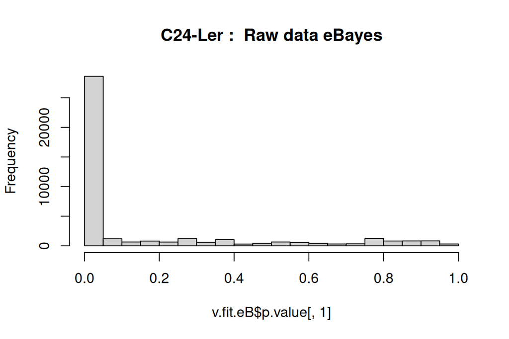

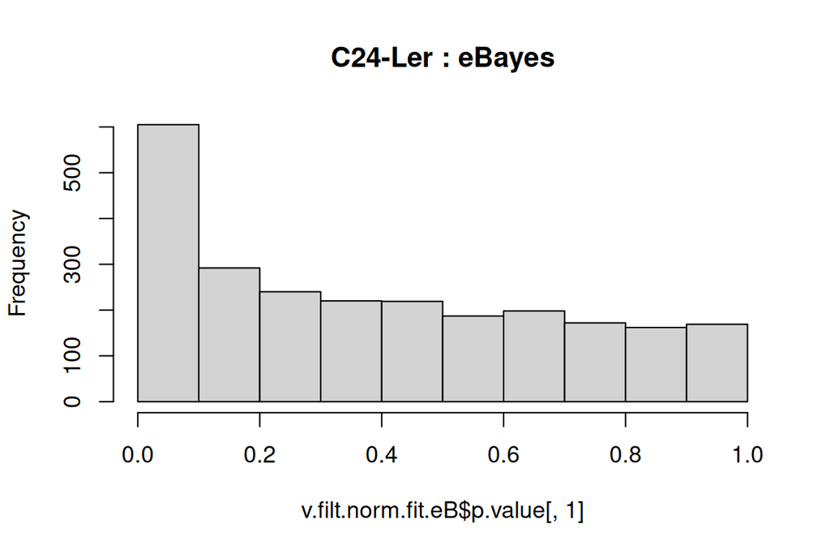

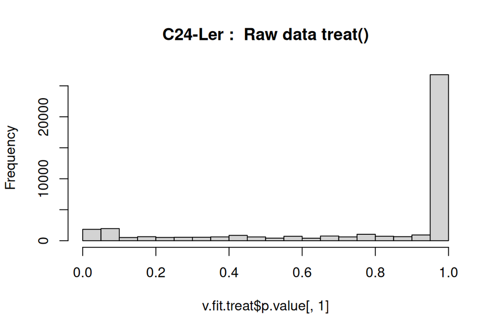

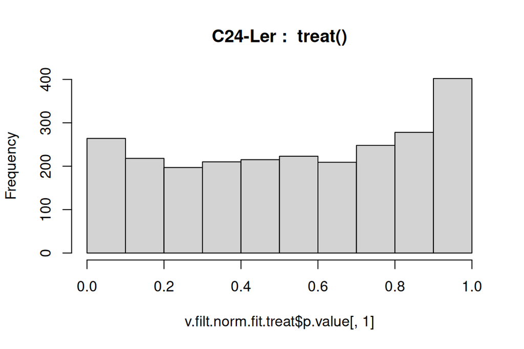

```r
theContrast <- colnames(v.fit.eB$p.value)[1]

# first row, data after eBayes()
hist(v.fit.eB$p.value[, 1],
     main = paste(theContrast, ": ", RAW_TXT, "eBayes"))
hist(v.filt.norm.fit.eB$p.value[, 1],
     main = paste(theContrast, ": eBayes"))

# second row, data after treat()
hist(v.fit.treat$p.value[, 1],
     main = paste(theContrast, ": ", RAW_TXT, "treat()"))
hist(v.filt.norm.fit.treat$p.value[, 1],
     main = paste(theContrast, ": ", "treat()"))
```

# Conclusiones de este trabajo

En este trabajo, se ha evidenciado la versatilidad de RStudio para desarrollar análisis bioinformáticos completos, facilitando la manipulación y visualización de datos complejos. Sin embargo, se ha observado que trabajar con un conjunto de datos de librerías cortas puede complicar ciertos procesos que funcionan con normalidad en otros tipos de datos. A lo largo del análisis, se evaluaron diferentes métodos estadísticos, destacando el enfoque de limma-voom GLM, que demostró ser efectivo para la identificación de genes expresados diferencialmente en el contexto de las limitaciones impuestas por las librerías cortas. Esta combinación de herramientas y métodos ha permitido obtener resultados significativos, subrayando la importancia de elegir adecuadamente las técnicas analíticas en función de la naturaleza del dataset.

# References

Note that the reference csl style [can be changed](https://github.com/citation-style-language/styles) to a different style.

Chen, Yunshun, Aaron T L Lun, and Gordon K Smyth. 2016. “From Reads to Genes to Pathways: Differential Expression Analysis of RNA-Seq Experiments Using Rsubread and the edgeR Quasi-Likelihood Pipeline.” *F1000Res* 5: 1438. https://doi.org/10.12688/f1000research.8987.2.

# Additional readings

- [Efficient library loading](https://www.r-bloggers.com/an-efficient-way-to-install-and-load-r-packages/)
- [Differential expression analysis with edgeR](https://gist.github.com/jdblischak/11384914)
- [Basic differential expression: EdgeR exact test](https://morphoscape.wordpress.com/2020/09/01/exact-tests-and-plots-with-edger-basic-differential-expression-analysis/)
- [Differential expression analyses of RNA-seq experiments using quasi-likelihood methods (QLF)](http://www.statsci.org/smyth/pubs/QLedgeRPreprint.pdf)
- [Advanced differential expression using generalised linear models (GLM)](https://morphoscape.wordpress.com/2020/09/26/generalized-linear-models-and-plots-with-edger-advanced-differential-expression-analysis/)
- Bioinformatics Analysis of Omics Data with the [Shell, R](https://morphoscape.wordpress.com/2022/07/28/bioinformatics-analysis-of-omics-data-with-the-shell-r/) and [edgeR](https://morphoscape.wordpress.com/2022/08/09/downstream-bioinformatics-analysis-of-omics-data-with-edger/)
- RNA-seq analysis is easy as 1-2-3: [artículo de 2018](https://doi.org/10.12688/f1000research.9005.3) y [paquete RNAseq123](http://bioconductor.org/packages/release/workflows/html/RNAseq123.html) en Bioconductor.
- Varet et al. 2016 SARTools: A DESeq2- and EdgeR-Based R Pipeline for Comprehensive Differential Analysis of RNA-Seq Data. [*PLoS ONE* 11(6): e0157022](https://journals.plos.org/plosone/article?id=10.1371/journal.pone.0157022), DOI 10.1371/journal.pone.0157022

# Information about this session

```r
# T00 calculated in execute_wf.R
Tff <- proc.time() # final time
T_total <- Tff - T00
print("Tiempo empleado en la ejecución:")
print(T_total)
```

```
## [1] "Tiempo empleado en la ejecución:"
##    user  system elapsed
##  12.011   1.655  16.995
```

El tiempo de reloj empleado: **0.28 min**.

```r
cat("Variables in memory:\n")
ls()
cat("\n")
sessionInfo()
```

```
## Variables in memory:
##  [1] "allContrasts"             "allFiles"                 "ARGS"
##  [4] "C1"                       "CHARS_TO_REMOVE"          "COL_NAMES"
##  [7] "COL_NUMBER"               "COMP_DETAILS"             "COMPUTER"
## [10] "COND_FREQ"                "contr.matrix"             "CONTRASTS"
## [13] "CreateDir"                "CTRL"                     "DANGER_bx"
## [16] "DATA_DIR"                 "degs.to.save.eB"          "design"
## [19] "doPlot"                   "dt.filt"                  "dt.norm"
## [22] "dt.raw"                   "eB.filt.norm.status.p.fc" "eB.filt.status.p.fc"
## [25] "eB.status.p.fc"           "errMsg"                   "EXP_COLORS"
## [28] "EXP_CONDITIONS"           "EXP_FACTORS"              "EXPAND_bx"
## [31] "FC"                       "fileName"                 "FILT_TXT"
## [34] "filt.degs"                "GetComputer"              "HOY"
## [37] "i"                        "INTERACTIVE_SESSION"      "LoadExpressionData"
## [40] "loadRmd"                  "logFC"                    "MIN_CPM"
```

[output cut: 67 more lines]